# Metody quasi-randomizacyjne: post-stratyfikacja

# 1 Wprowadzenie

Wczytujemy pakiet `tidyverse`.

```r
library(tidyverse)
library(knitr)
library(survey)
library(Hmisc) ## wtd.var to calculate weighted variance
```

Wczytujemy dane na potrzeby zajęć.

```r
dane <- read_csv("../data/popyt-zajecia-dane.csv")
```

| id_popyt | id_jednostki | waga | sek | klasa_pr | sekc_pkd | woj | zawod_kod2 | wolne_miejsca | id_cbop | jedna_zmiana | wymiar_40 | wolne_miejsca_cbop | wolne_miejsca_niepeln_cbop |
| --- | --- | --- | --- | --- | --- | --- | --- | --- | --- | --- | --- | --- | --- |
| 1 | a9cc990df6a99ab215a1bc13f51d4825c7d52d18 | 1 | 1 | D | O | 14 | 1 | 2 | NA | NA | NA | NA | NA |
| 2 | a9cc990df6a99ab215a1bc13f51d4825c7d52d18 | 1 | 1 | D | O | 14 | 2 | 7 | NA | NA | NA | NA | NA |
| 3 | c9dbaf50890165ebe810aa770de0e9df903dc35b | 6 | 1 | D | O | 24 | 2 | 6 | NA | NA | NA | NA | NA |
| 4 | 718e0bba42bcec6ed98f9690db6d26cb7b93c880 | 1 | 1 | D | R.S | 14 | 2 | 7 | NA | NA | NA | NA | NA |
| 5 | 532a1879a692b9d7bbb7282ba757d028156ef341 | 1 | 1 | D | R.S | 14 | 2 | 6 | NA | NA | NA | NA | NA |
| 6 | 0b6b623fa45e257284a3049d097af322841337e3 | 1 | 1 | D | R.S | 22 | 2 | 1 | NA | NA | NA | NA | NA |

# 2 Przykłady

## 2.1 Prosty przykład na potrzeby wykładów

1. Wyznaczamy wielkość populacji – estymowana liczba wakatów.

```r
dane |>
  filter(!is.na(id_popyt)) |>
  count(klasa_pr, wt = wolne_miejsca*waga, name = "N") -> pop_data
```

| klasa_pr | N |
| --- | --- |
| D | 94124 |
| M | 128940 |
| S | 71230 |

2. Wyznaczamy odsetek wakatów oferowanych na jedną zmianę.

```r
dane |>
  filter(!is.na(id_cbop)) |>
  group_by(klasa_pr) |>
  summarise(y = weighted.mean(jedna_zmiana, wolne_miejsca_cbop),
            y_var = wtd.var(jedna_zmiana, wolne_miejsca_cbop),
            n = sum(wolne_miejsca_cbop)) -> tab_cbop
```

| klasa_pr | y | y_var | n |
| --- | --- | --- | --- |
| D | 0.2978421 | 0.2091463 | 14783 |
| M | 0.7596395 | 0.1826143 | 6769 |
| S | 0.7021184 | 0.2091785 | 6892 |

3. Dodajemy informację o wielkości populacji.

```r
tab_cbop |>
  left_join(pop_data, by = "klasa_pr") |>
  mutate(W_h = N/sum(N))  -> tab_przyklad
```

| klasa_pr | y | y_var | n | N | W_h |
| --- | --- | --- | --- | --- | --- |
| D | 0.2978421 | 0.2091463 | 14783 | 94124 | 0.3198298 |
| M | 0.7596395 | 0.1826143 | 6769 | 128940 | 0.4381333 |
| S | 0.7021184 | 0.2091785 | 6892 | 71230 | 0.2420369 |

4. Wyznaczamy dwa estymatory odsetka wakatów oferowanych na jedną zmianę: `y_naive` – zwykła średnia ze zbioru danych, `y_ps` – estymator post-stratyfikowany. Wyznaczamy również wariancję zgodnie ze wzorem

$$V\left(\bar{y}_{PS}\right)=\left(\frac{1}{n}-\frac{1}{N}\right) \sum_{h=1}^{L} W_{h} S_{h}^{2}+\frac{1}{n^{2}} \sum_{h=1}^{L}\left(1-W_{h}\right) S_{h}^{2}$$

```r
tab_przyklad |>
  summarise(y_naive = weighted.mean(y, n),
            y_ps = sum(y*W_h),
            y_ps_var = (1/sum(n) - 1/sum(N))*sum(W_h*y_var) + 1/sum(n)^2*sum((1-W_h)*y_var),
            y_ps_sd = sqrt(y_ps_var)) -> wynik
```

| y_naive | y_ps | y_ps_var | y_ps_sd |
| --- | --- | --- | --- |
| 0.5056954 | 0.5980207 | 6.3e-06 | 0.0025048 |

## 2.2 Przykład z wykorzystaniem pakietu survey

1. Tworzymy podzbiór z potrzebnymi danymi, w której kolumnę `wolne_miejsca_cbop` traktujemy jako wagę wejściową ponieważ jeden wiersz odpowiada za jednen lub więcej wakatów.

```r
dane |>
  filter(is.na(id_popyt)) |>
  select(id_jednostki, klasa_pr, sek, woj, zawod_kod2, wolne_miejsca_cbop, jedna_zmiana) |>
  mutate(jedna_zmiana=as.numeric(jedna_zmiana)) -> cbop_df
```

| id_jednostki | klasa_pr | sek | woj | zawod_kod2 | wolne_miejsca_cbop | jedna_zmiana |
| --- | --- | --- | --- | --- | --- | --- |
| 03950533c4990dd3e6b80312d98d7bf7877d6cdc | D | 1 | 22 | 2 | 1 | 1 |
| fc1e0932170f7ec7da987a060bfb7ab01a928b3f | D | 1 | 14 | 9 | 2 | 1 |
| ec812df7c443d9681645795c35687241418466ea | D | 1 | 12 | 5 | 3 | 0 |
| ec812df7c443d9681645795c35687241418466ea | D | 1 | 12 | 9 | 4 | 1 |
| f59016808a975f0f45ab571899d50d4931cebaeb | D | 1 | 24 | 2 | 2 | 1 |
| 76f26af4360f38e53850ea0628131fd7a8c51a82 | D | 1 | 04 | 2 | 1 | 1 |

2. Tworzymy obiekt `svydesign`

```r
cbop_svy <- svydesign(ids = ~1,
                      weights = ~ wolne_miejsca_cbop,
                      data = cbop_df)
cbop_svy
```

```
Independent Sampling design (with replacement)
svydesign(ids = ~1, weights = ~wolne_miejsca_cbop, data = cbop_df)
```

3. Estymator naiwny na podstawie danych jednostkowych

```r
svymean(~jedna_zmiana, cbop_svy)
```

```
                mean     SE
jedna_zmiana 0.52046 0.0136
```

### 2.2.1 Post-stratyfikacja z wykorzystaniem zmiennej `klasa_pr`

1. Wyznaczamy wartości globalne na potrzeby post-stratyfikacji zgodnie z wymogami funkcji `postStratify`

```r
pop_totals <- xtabs(wolne_miejsca*waga ~ klasa_pr, data= dane, subset = !is.na(id_popyt))
pop_totals
```

```
klasa_pr
     D      M      S
 94124 128940  71230
```

2. Dokonujemy post-stratyfikacji

```r
cbop_svy_ps <- postStratify(cbop_svy, strata = ~klasa_pr, population = pop_totals)
cbop_svy_ps
```

```
Independent Sampling design (with replacement)
postStratify(cbop_svy, strata = ~klasa_pr, population = pop_totals)
```

3. Estymator post-stratyfikacyjny

```r
svymean(~jedna_zmiana, cbop_svy_ps)
```

```
                mean     SE
jedna_zmiana 0.60006 0.0079
```

### 2.2.2 Post-stratyfikacja z wykorzystaniem większej liczby zmiennych

1. Wyznaczamy wartości globalne na potrzeby post-stratyfikacji zgodnie z wymogami funkcji `postStratify` dla dwóch zmiennych

```r
pop_totals2 <- xtabs(wolne_miejsca*waga ~ klasa_pr + zawod_kod2, data= dane, subset = !is.na(id_popyt))
pop_totals2
```

```
        zawod_kod2
klasa_pr     1     2     3     4     5     7     8     9
       D  4235 22547  9086  8351 13643 16569 13587  6106
       M  5710  8019  7250 11248 23771 40370 22826  9746
       S  1353  8575  3487  7815 14295 16627 10733  8345
```

2. Dokonujemy post-stratyfikacji z wykorzystaniem dwóch zmiennych

```r
cbop_svy_ps2 <- postStratify(cbop_svy, strata = ~klasa_pr + zawod_kod2, population = pop_totals2)
cbop_svy_ps2
```

```
Independent Sampling design (with replacement)
postStratify(cbop_svy, strata = ~klasa_pr + zawod_kod2, population = pop_totals2)
```

3. Sprawdzamy czy uzyskane wagi odzwierciedlają wartości globalne `pop_totals2`

```r
svytable( ~klasa_pr + zawod_kod2, cbop_svy_ps2)
```

```
        zawod_kod2
klasa_pr     1     2     3     4     5     7     8     9
       D  4235 22547  9086  8351 13643 16569 13587  6106
       M  5710  8019  7250 11248 23771 40370 22826  9746
       S  1353  8575  3487  7815 14295 16627 10733  8345
```

4. Możemy również porównać wagi wejściowe (przed post-stratyfikacją) z wagami końcowymi (po post-stratyfikacji).

```r
summary(weights(cbop_svy_ps2)/weights(cbop_svy))
```

```
   Min. 1st Qu.  Median    Mean 3rd Qu.    Max.
  1.804   7.184  11.578  13.760  18.476 154.324
```

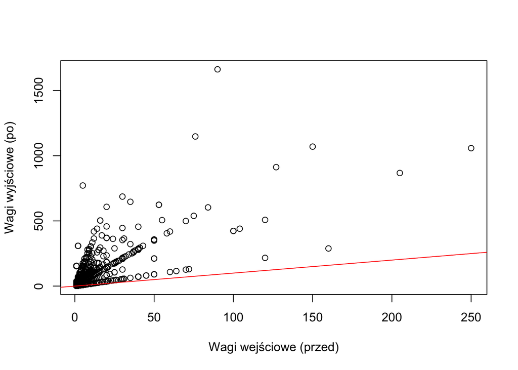

```r
plot(weights(cbop_svy), weights(cbop_svy_ps2), xlab = "Wagi wejściowe (przed)", ylab = "Wagi wyjściowe (po)")
abline(a=0,b=1,col="red")
```

5. Estymator post-stratyfikacyjny

```r
svymean(~jedna_zmiana, cbop_svy_ps2)
```

```
                mean     SE
jedna_zmiana 0.63526 0.0076
```

# 3 Badanie symulacyjne

## 3.1 Definicja procesu generowania danych

Rozważmy następujący układ:

- Wielkość populacji $N=10000$
- Dwie cechy $X$:

$$\begin{align}
X_1 & \sim \text{Bernoulli}(0.7) \\
X_2 & \sim \text{Bernoulli}(0.9) \\
\end{align}$$
+ Model dla cechy Y

$$Y = 4.5 - 3.5X_1 + 0.5X_2 + \epsilon; \quad \epsilon \sim N(0,1)$$

- Próba nielosowa o wielkości $n_b=1000$ jest generowana proporcjonalnie do cechy $Y$, gdzie prawdopodobieństwo wylosowania danego rekordu określone jest w następujący sposób:

$$P(R_i = 1) = \frac{|y_i|}{\sum_{i=1}^N |y_i|}$$
Dla tak uzyskanej próby nielosowej należy:

- ocenić różnice w rozkładach X między próbą, a populacją,
- ocenić zależność między cechą X1 i X2
- dokonać post-stratyfikacji z wykorzystaniem pakietu `survey`.

## 3.2 Rozwiązanie

Kod R do generowania danych

```r
set.seed(2023)
N <- 10000
nb <- 1000
X1 <- rbinom(N, 1, 0.7)
X2 <- rbinom(N, 1, 0.9)
Y <- 4.5 - 3.5*X1+0.5*X2 + rnorm(N)
nb_inds <- sample(1:N, size = nb, prob = abs(Y)/sum(abs(Y)))
flag <- 1:N %in% nb_inds
w_star <- N/nb ## dodajemy pseudo-wagę jako relację miedzy N / nb
df <- data.frame(Y,X1,X2,flag,w_star)
head(df)
```

```
          Y X1 X2  flag w_star
1 2.6962638  1  0 FALSE     10
2 1.6924790  1  1 FALSE     10
3 0.6321686  1  1 FALSE     10
4 1.2589372  1  1 FALSE     10
5 1.5824627  1  0 FALSE     10
6 2.1429458  1  0 FALSE     10
```

Porównajmy rozkłady $X_1$ i $X_2$

```r
pop_X1 <- mean(df$X1)
pop_X2 <- mean(df$X2)
sam_X1 <- mean(df$X1[df$flag == 1])
sam_X2 <- mean(df$X2[df$flag == 1])
c(X1_pop = pop_X1, X2_pop = pop_X2, X1_proba = sam_X1, X2_proba = sam_X2)
```

```
  X1_pop   X2_pop X1_proba X2_proba
  0.7072   0.9036   0.4510   0.9140
```

Rozkład łączny $X_1$ i $X_2$ – różnica w odsetkach między próbą, a populacją.

```r
prop.table(xtabs(~X1 + X2, df, subset = flag == T)) - prop.table(xtabs(~X1 + X2, df))
```

```
   X2
X1        0       1
  0  0.0259  0.2303
  1 -0.0363 -0.2199
```

Jaka jest zależność między $Y$, a $X_1$ oraz $X_2$?

```r
m1 <- lm(Y ~ X1 + X2, data = df, subset = flag == TRUE)
summary(m1)
```

```
Call:
lm(formula = Y ~ X1 + X2, data = df, subset = flag == TRUE)

Residuals:
     Min       1Q   Median       3Q      Max
-3.09126 -0.67897 -0.04242  0.66475  2.79378

Coefficients:
            Estimate Std. Error t value Pr(>|t|)
(Intercept)  4.76611    0.10602  44.956  < 2e-16 ***
X1          -3.05386    0.06121 -49.893  < 2e-16 ***
X2           0.37289    0.10863   3.433 0.000623 ***
---
Signif. codes:  0 '***' 0.001 '**' 0.01 '*' 0.05 '.' 0.1 ' ' 1

Residual standard error: 0.9616 on 997 degrees of freedom
Multiple R-squared:  0.7141,    Adjusted R-squared:  0.7135
F-statistic:  1245 on 2 and 997 DF,  p-value: < 2.2e-16
```

Funkcją anova możemy sprawdzić jak dana zmienna wpływa na redukcję sumy kwadratów odchyleń (SSQ).

```r
anova(m1)
```

```
Analysis of Variance Table

Response: Y
           Df  Sum Sq Mean Sq  F value    Pr(>F)
X1          1 2291.43 2291.43 2477.928 < 2.2e-16 ***
X2          1   10.90   10.90   11.782 0.0006226 ***
Residuals 997  921.96    0.92
---
Signif. codes:  0 '***' 0.001 '**' 0.01 '*' 0.05 '.' 0.1 ' ' 1
```

Wnioski:

- główna rozbieżność w zmiennej $X_1$, w $X_2$ niezbyt,
- zmienna $X_1$ jest silniej skorelowana z $Y$ niż $X_2$.

Dokonujemy post-stratyfikacji wg dwóch zmiennych

```r
totale <- xtabs(~X1 + X2, data = df)
dd <- svydesign(ids= ~1, weights = ~w_star, data = subset(df, flag == T))
dd2 <- postStratify(dd, strata= ~X1+X2, population = totale)
c(Y_prawda = mean(Y), Y_bez_ps = svymean(~Y, dd)[1], Y_ps = svymean(~Y, dd2)[1])
```

```
  Y_prawda Y_bez_ps.Y     Y_ps.Y
  2.482548   3.729640   2.946133
```

Jeżeli użyjemy wyłącznie $X_1$ uzyskamy następujące wyniki

```r
totale <- xtabs(~X1 , data = df)
dd <- svydesign(ids= ~1, weights = ~w_star, data = subset(df, flag == T))
dd2 <- postStratify(dd, strata= ~X1, population = totale)
c(Y_prawda = mean(Y), Y_bez_ps = svymean(~Y, dd)[1], Y_ps = svymean(~Y, dd2)[1])
```

```
  Y_prawda Y_bez_ps.Y     Y_ps.Y
  2.482548   3.729640   2.950244
```

Jeżeli użyjemy wyłącznie $X_2$ uzyskamy następujące wyniki

```r
totale <- xtabs(~X2 , data = df)
dd <- svydesign(ids= ~1, weights = ~w_star, data = subset(df, flag == T))
dd2 <- postStratify(dd, strata= ~X2, population = totale)
c(Y_prawda = mean(Y), Y_bez_ps = svymean(~Y, dd)[1], Y_ps = svymean(~Y, dd2)[1])
```

```
  Y_prawda Y_bez_ps.Y     Y_ps.Y
  2.482548   3.729640   3.728908
```

Wnioski:

- użycie $X_1$ redukuje obciązenie, a $X_2$ nie wpływa na wyniki,
- zredukowano obciążenie ale częściowo dlatego, że dobór próby był wyłącznie zależny od cechy Y, a nie od X1 i X2.

Wykonajmy to ćwiczenie 500 razy

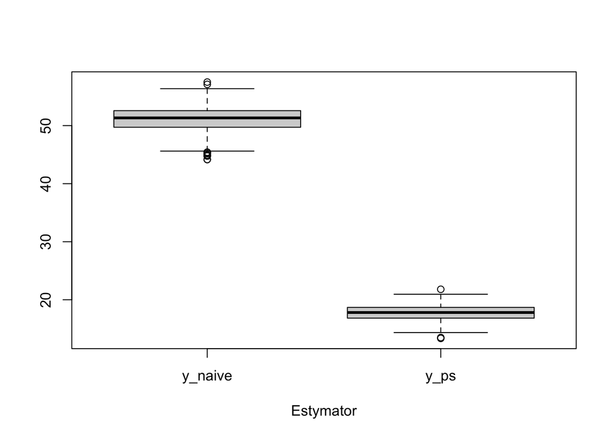

```r
R <- 500
y_naive <- numeric(R)
y_ps <- numeric(R)
totale <- xtabs(~X1+X2 , data = df)
for (r in 1:500) {
  nb_inds <- sample(1:N, size = nb, prob = abs(Y)/sum(abs(Y)))
  flag <- 1:N %in% nb_inds
  w_star <- N/nb ## dodajemy pseudo-wagę jako relację miedzy N / nb
  df <- data.frame(Y,X1,X2,flag,w_star)

  dd <- svydesign(ids= ~1, weights = ~w_star, data = subset(df, flag == T))
  dd2 <- postStratify(dd, strata= ~X1+X2, population = totale)

  y_naive[r] <- svymean(~Y, dd)[1]
  y_ps[r] <- svymean(~Y, dd2)[1]
}

boxplot((cbind(y_naive, y_ps) - mean(Y))/mean(Y)*100, xlab = "Estymator", y = "Relatywne obciążenie (w %)")
```

Wyniki symulacji

```r
oszacowanie <- c(mean(y_naive), mean(y_ps))
obciazenie <- c(mean(y_naive), mean(y_ps)) -mean(Y)
wariancja <- c(var(y_naive), var(y_ps))
rmse <- c(sqrt(obciazenie^2+wariancja))
data.frame(estymator=c("naiwny", "poststratyfikacyjny"), oszacowanie, obciazenie, wariancja, rmse)
```

```
            estymator oszacowanie obciazenie   wariancja      rmse
1              naiwny    3.752084  1.2695367 0.003138566 1.2707723
2 poststratyfikacyjny    2.924529  0.4419818 0.001054434 0.4431731
```

# 4 Podsumowanie

- Post-stratyfikacja wymaga znajomości wartości globalnych.
- Post-stratyfikacja nie wymaga skomplikowanych procedur (można to zrobić w bazie SQL/MS Excel).
- Estymator wariancji estymatora post-stratyfikacyjnego zakłada, że próba nielosowa jest próbą prostą z populacji.